```python
import numpy as np
import pandas as pd
import matplotlib.pyplot as plt
import seaborn as sns
from scipy import stats
from scipy.optimize import minimize
from scipy.stats import norm, t
from scipy.integrate import quad
```

# 1. Explore the weekly data set (market_data.csv)

## a) Plot the evolution of the stocks and the interest rates over the period 1996-01-01 -> 2024-12-31, in two separate plots (with legends). Normalize all the stock prices so that they have an initial price of 100 enabling a fair comparison of their performances. Do not normalize the rates.

Method

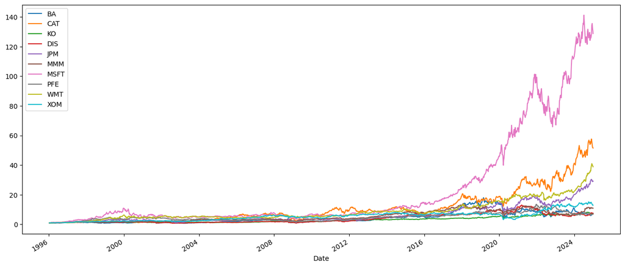

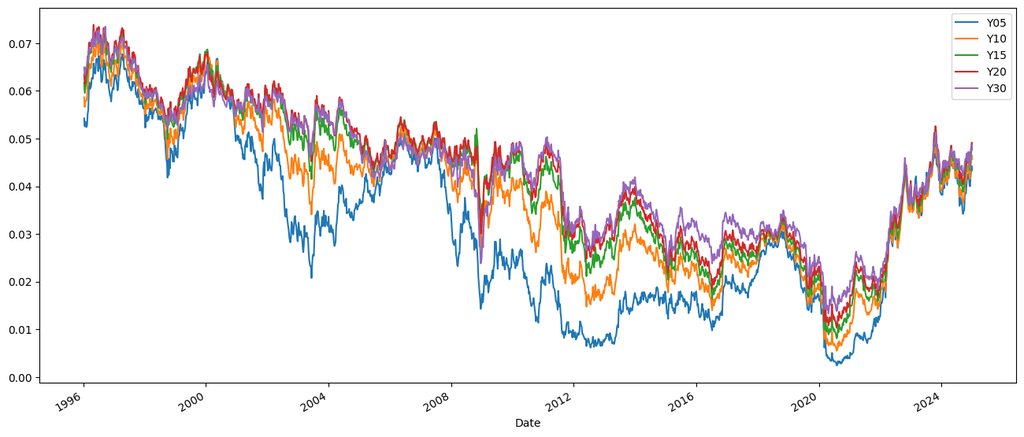

```python
df = pd.read_csv('market_data.csv', sep= ";", index_col = "Date", parse_dates = True)

#Stocks
stocks = df.drop(df.columns[10:], axis = 1)
normalized = stocks / stocks.iloc[0]
normalized.plot(figsize = (16, 7))

#interests
interest = df.drop(df.columns[:10], axis = 1)
interest.plot(figsize = (16, 7))
```

## b) Determine for each stock (and present in a table):

- the annualized mean log-return,
- the annualized volatility of log-returns,
- the 5th and the 95th log-return percentiles, and
- the minimum and maximum log-return.

Method:

- Calculated daily percentage returns for each stock and converted them to log-returns.
- Computed annualized mean log-returns by multiplying average daily log-returns by 52 (weeks per year).
- Determined annualized volatility as the standard deviation of log-returns scaled by √52.
- Found the 5th and 95th percentiles of log-returns to measure lower and upper extremes.
- Identified the minimum and maximum log-returns for each stock.

```python
daily_returns = stocks.pct_change().dropna()
log_stocks = np.log(1 + daily_returns)

annual_mean = log_stocks.mean() * 52
annual_volatility = log_stocks.std() * np.sqrt(52)
percentile_5 = log_stocks.quantile(0.05)
percentile_95 = log_stocks.quantile(0.95)
maxlog = log_stocks.max()
minlog = log_stocks.min()

df_1 = pd.DataFrame()
df_1["Annual Mean Ret"] = annual_mean
df_1["Annual Vol"] = annual_volatility
df_1["5th per."] = percentile_5
df_1["95th per."] = percentile_95
df_1["Max log return"] = maxlog
df_1["Min log return"] = minlog

df_1
```

|  | Annual Mean Ret | Annual Vol | 5th per. | 95th per. | Max log return | Min log return |
| --- | --- | --- | --- | --- | --- | --- |
| BA | 0.068802 | 0.381345 | -0.075137 | 0.072227 | 0.533614 | -0.582992 |
| CAT | 0.135586 | 0.325468 | -0.072680 | 0.075442 | 0.269244 | -0.224978 |
| KO | 0.067536 | 0.221468 | -0.045082 | 0.046805 | 0.111502 | -0.236452 |
| DIS | 0.069119 | 0.283881 | -0.059509 | 0.064126 | 0.163325 | -0.277276 |
| JPM | 0.115929 | 0.355391 | -0.075636 | 0.070351 | 0.399379 | -0.416844 |
| MMM | 0.082272 | 0.237975 | -0.054328 | 0.051208 | 0.201825 | -0.174427 |
| MSFT | 0.167087 | 0.284445 | -0.057946 | 0.067767 | 0.209798 | -0.211152 |
| PFE | 0.066329 | 0.254311 | -0.051797 | 0.057840 | 0.133069 | -0.227099 |
| WMT | 0.125894 | 0.240542 | -0.050385 | 0.053804 | 0.167702 | -0.216747 |
| XOM | 0.088201 | 0.241481 | -0.051336 | 0.053314 | 0.154748 | -0.223983 |

## c) Determine the correlation matrix for the log-returns of all stocks and interest rates and plot as a heatmap, together with the values formatted as percent.

Method:

- Calculated daily percentage changes for all stocks and interest rates, then converted them to log-returns.
- Computed the correlation matrix of these log-returns to measure relationships between variables.
- Used a heatmap to visually display the correlation values.

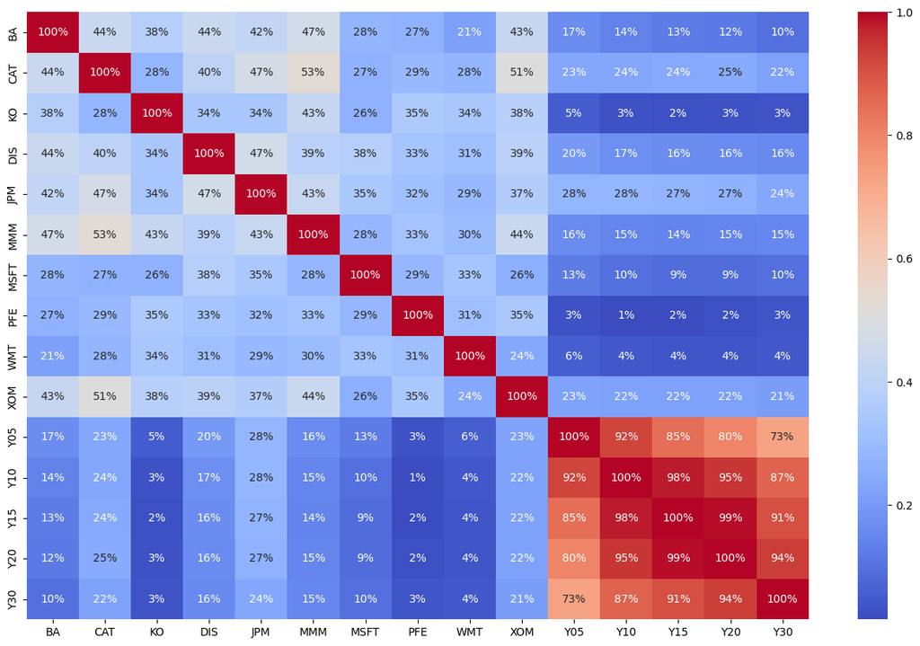

```python
df_day_ret = df.pct_change().dropna()
log_ret = np.log(1 + df_day_ret)

plt.figure(figsize = (16,10))
heatplot = sns.heatmap(log_ret.corr(), cmap ="coolwarm", annot=True, fmt= ".0%")
plt.show()
```

# 2. VAR(1)-model

Estimate a VAR(1)-model for the market.

## a) Estimate the parameters (include them in the report) and check whether the model is stable or not

(this check should also be detailed in the report).

Method:

- Computed log-returns for all variables and selected the stock-related columns for the VAR(1) analysis.
- Defined lagged values of the log-returns as variables and built the regression matrix with ones in the first column.
- Estimated the VAR(1) parameters for each stock using the normal equation.
- Stored the estimated intercepts and coefficients in a parameter table.
- Formed the coefficient matrix (A) from lagged parameters and calculated its eigenvalues.
- Checked model stability by confirming that all eigenvalues lie inside the unit circle (absolute value < 1).

```python
log_returns = np.log(df).diff().dropna()
stock_cols = list(range(0, 15))  # columns 2 to 11

log_returns_stocks = log_returns.iloc[:, stock_cols]
T, K = log_returns_stocks.shape

M = np.hstack([np.ones((T-1, 1)),log_returns_stocks.values[:-1, :]])
parameters = []
for k in range(K):
    Y_k = log_returns_stocks.values[1:, k]
    a_k = np.linalg.inv(M.T @ M) @ M.T @ Y_k #normalekvationen
    parameters.append(a_k)

tickers = ["BA", "CAT", "KO", "DIS", "JPM", "MMM", "MSFT", "PFE", "WMT", "XOM", "Y05", "Y10", "Y15", "Y20", "Y30"]

param_matrix = np.vstack(parameters)  #  (K, K+1)
row_labels = tickers
col_labels = ["A0"] + [f"A_{t}" for t in tickers]

param_df = pd.DataFrame(param_matrix, index=row_labels, columns=col_labels)

A = np.vstack([a_k[1:] for a_k in parameters])  #  (K, K)

eigvals = np.linalg.eigvals(A)
```

```python
param_df
```

|  | A0 | A_BA | A_CAT | A_KO | A_DIS | A_JPM | A_MMM | A_MSFT | A_PFE | A_WMT | A_XOM | A_Y05 | A_Y10 | A_Y15 | A_Y20 | A_Y30 |
| --- | --- | --- | --- | --- | --- | --- | --- | --- | --- | --- | --- | --- | --- | --- | --- | --- |
| BA | 0.001470 | -0.085038 | 0.134290 | -0.017806 | 0.001229 | -0.064860 | -0.133235 | -0.015479 | 0.012330 | -0.045659 | 0.080811 | 0.484297 | -3.348185 | 7.076209 | -4.939085 | 0.728075 |
| CAT | 0.002502 | 0.003637 | 0.001858 | -0.048406 | 0.040368 | -0.012726 | 0.011745 | 0.032633 | -0.020052 | 0.038015 | -0.039788 | 0.224225 | -1.428710 | 2.760569 | -1.966486 | 0.379313 |
| KO | 0.001447 | 0.025548 | 0.044695 | -0.051168 | -0.005958 | -0.020614 | -0.062136 | -0.013113 | 0.041451 | -0.067731 | 0.042464 | 0.257914 | -1.675525 | 3.102762 | -2.021002 | 0.335519 |
| DIS | 0.001259 | 0.016087 | 0.033225 | -0.038202 | -0.032535 | 0.013546 | 0.060702 | -0.024126 | -0.018249 | 0.029081 | -0.026656 | 0.140776 | -1.156560 | 2.573411 | -1.874524 | 0.281520 |
| JPM | 0.002039 | 0.014906 | 0.062840 | -0.013515 | 0.047359 | -0.169044 | -0.032855 | 0.051056 | 0.078081 | 0.043122 | -0.019513 | 0.310323 | -1.818882 | 3.748871 | -2.640174 | 0.337923 |
| MMM | 0.001771 | 0.039316 | 0.096859 | 0.018668 | -0.041314 | -0.067598 | -0.095080 | -0.042339 | 0.040051 | 0.008293 | -0.038469 | 0.160211 | -0.984241 | 1.591016 | -0.828044 | 0.089847 |
| MSFT | 0.003418 | 0.020273 | -0.017588 | -0.037093 | -0.014736 | 0.033225 | -0.031525 | 0.012107 | -0.030299 | -0.053637 | -0.034175 | 0.174341 | -1.068987 | 1.988965 | -1.278009 | 0.167076 |
| PFE | 0.001310 | 0.017621 | 0.023053 | -0.037290 | -0.023130 | -0.047356 | 0.006877 | 0.037125 | -0.052517 | 0.010703 | -0.018229 | 0.060544 | -0.487635 | 0.767735 | -0.306821 | -0.063744 |
| WMT | 0.002837 | 0.043665 | 0.010588 | 0.007679 | -0.081566 | 0.006934 | -0.008845 | 0.039133 | -0.002337 | -0.138461 | -0.068611 | -0.065290 | 0.127217 | -0.310301 | 0.451298 | -0.202592 |
| XOM | 0.001860 | -0.003837 | 0.059203 | -0.066267 | 0.033325 | -0.056082 | -0.008365 | -0.004300 | 0.011582 | -0.000838 | -0.083424 | 0.329995 | -2.023874 | 4.026742 | -2.697977 | 0.368999 |
| Y05 | -0.000201 | -0.007493 | -0.004801 | 0.004238 | 0.057183 | 0.001254 | -0.069035 | -0.010931 | -0.010429 | 0.006502 | 0.078369 | 0.276991 | -1.056317 | 0.886899 | -0.129990 | -0.092215 |
| Y10 | -0.000173 | -0.039004 | -0.021567 | -0.002517 | 0.056360 | 0.015095 | -0.047183 | -0.010616 | -0.006337 | 0.017373 | 0.053176 | 0.218252 | -0.592200 | 0.313784 | 0.022131 | -0.061646 |
| Y15 | -0.000162 | -0.031180 | -0.022865 | -0.013131 | 0.056931 | 0.016081 | -0.039592 | -0.009124 | -0.007639 | 0.010959 | 0.046980 | 0.147359 | -0.354744 | 0.215687 | -0.104256 | 0.003224 |
| Y20 | -0.000165 | -0.019348 | -0.021398 | -0.017399 | 0.052972 | 0.014611 | -0.033549 | -0.009629 | -0.008643 | 0.006806 | 0.043735 | 0.155544 | -0.473710 | 0.545107 | -0.371517 | 0.050354 |
| Y30 | -0.000194 | -0.014780 | -0.020608 | -0.007520 | 0.039718 | 0.008386 | -0.017727 | -0.007612 | -0.009640 | 0.011614 | 0.026268 | 0.200506 | -0.476120 | 0.106745 | 0.194476 | -0.120080 |

```python
# Check stability
is_stable = np.all(np.abs(eigvals) < 1)
print("Eigenvalues:", eigvals)
print("Stable VAR(1):", is_stable)
```

```
Eigenvalues: [-0.0947655 +0.18792707j -0.0947655 -0.18792707j -0.25134842+0.j
 -0.1713057 +0.0613468j  -0.1713057 -0.0613468j  -0.08002967+0.09798378j
 -0.08002967-0.09798378j  0.0147666 +0.01846628j  0.0147666 -0.01846628j
 -0.01347254+0.05270647j -0.01347254-0.05270647j -0.12003013+0.j
 -0.08458639+0.02736633j -0.08458639-0.02736633j -0.05425707+0.j        ]
Stable VAR(1): True
```

## b) Calculate the volatilities of the VAR-residuals and include them in the report.

Method:

- Computed the predicted log-returns for each stock using the estimated VAR(1) parameters.
- Calculated residuals by subtracting predicted values from the actual log-returns.
- Determined the volatility of each stock’s residuals using the standard deviation across time.

```python
# Calculate residuals for each stock equation
residuals_matrix = np.zeros((T-1, K))  # Shape: (number of time steps, number of stocks)
for k in range(K):
    Y_k = log_returns_stocks.values[1:, k]
    Yhat_k = M @ parameters[k]  # Predicted values
    residuals_matrix[:, k] = Y_k - Yhat_k #residuals

residuals_cat = residuals_matrix[:, 1]

# Calculate volatility (std deviation) of residuals for each stock
volatilities = np.std(residuals_matrix, axis=0, ddof=1)

# Print volatilities
print("\nVolatilities (standard deviations) of VAR residuals:")
for ticker, vol in zip(tickers, volatilities):
    print(f"{ticker}: {vol:.6f}")
```

```
Volatilities (standard deviations) of VAR residuals:
BA: 0.051667
CAT: 0.044917
KO: 0.030189
DIS: 0.039135
JPM: 0.048443
MMM: 0.032395
MSFT: 0.039135
PFE: 0.034939
WMT: 0.032527
XOM: 0.032846
Y05: 0.060497
Y10: 0.045395
Y15: 0.038467
Y20: 0.034834
Y30: 0.033500
```

## c) Simulate 5000 scenarios with 480 weekly time steps for all assets and plot the price (or interest rate) percentiles (5%, 10%, 25%, 50%, 75%, 90%, 95%) for the stocks Caterpillar and Walmart and the 5- and 30-year interest rates. A total of four plots. Also list these percentiles, for the time periods 240 and 480, in two tables with the percentiles in the horizontal direction and the stocks and interest rates in the vertical direction.

Method:

- Estimated the residual covariance of the VAR(1) and obtained a Cholesky factor to generate correlated shocks.
- Initialized the VAR state with the last observed weekly log-returns and simulated 5,000 scenarios over 480 weeks by iterating the VAR(1) recursion.
- Cumulated simulated log-returns to get cumulative log-returns, then transformed back to price/level paths using the last observed values as starting points.
- For each of CAT, WMT, Y05, and Y30, computed time-series percentiles across scenarios and plotted these percentile curves.
- Formed two tables with percentiles in columns and the four assets in rows.

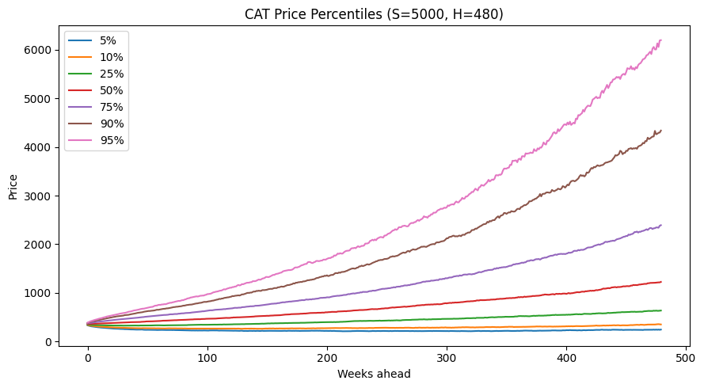

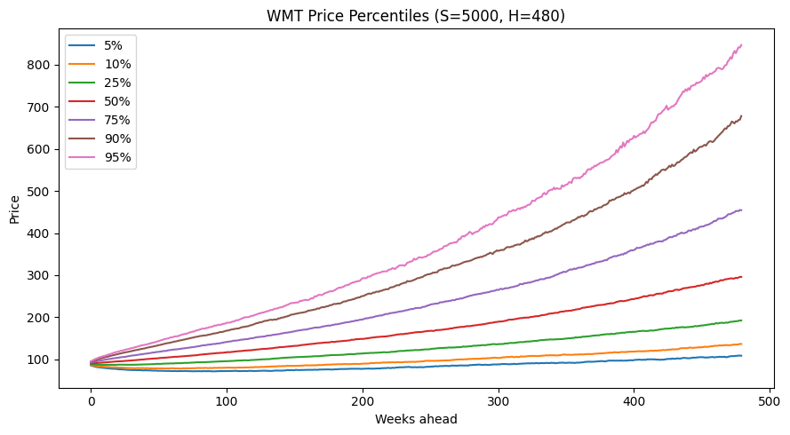

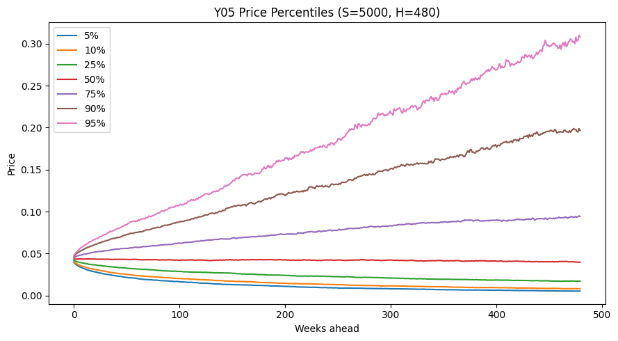

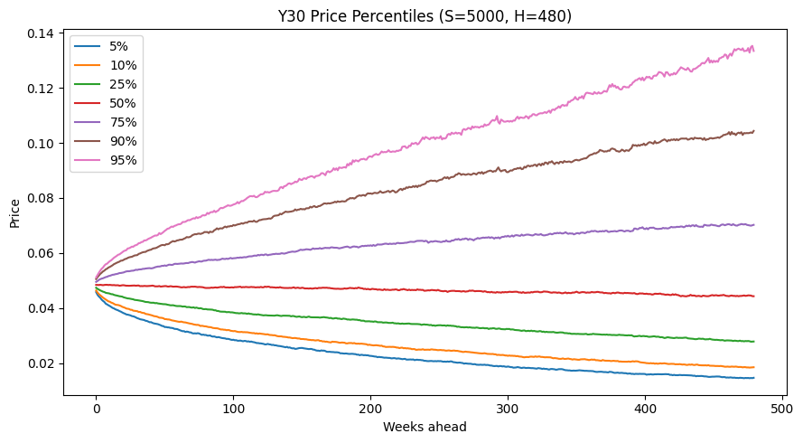

```python
cov_matrix = np.cov(residuals_matrix, rowvar=False)
C = np.linalg.cholesky(cov_matrix) #lower triangualr matrix

A0 = param_matrix[:, 0]

steps = 480        # horizon (weeks)
n = 5000       # scenarios

# Start state for the VAR in returns: last observed return vector (1xK)
y_last = log_returns_stocks.values[-1]  # shape (K,)

# paths of returns: (5000, 480, 10)
ret_paths = np.zeros((n, steps, K))
y_prev = np.tile(y_last, (n, 1))  # (5000,10)

for t in range(steps):
    Z = np.random.randn(n, K)
    eps = Z @ C.T
    y_t = A0 + y_prev @ A.T + eps
    ret_paths[:, t, :] = y_t
    y_prev = y_t

P0 = df.iloc[-1, stock_cols].values

# cumulative log-returns over time
cum_log_ret = np.cumsum(ret_paths, axis=1)        # (5000,480,10)

price_paths_VAR = np.exp(cum_log_ret) * P0

#Percentile plots for CAT and WMT
assets_to_plot = ["CAT", "WMT", "Y05", "Y30"]
percentiles = [5, 10, 25, 50, 75, 90, 95]
indices_assets = [tickers.index(asset) for asset in assets_to_plot]

for asset in assets_to_plot:
    idx = tickers.index(asset)
    q = np.percentile(price_paths_VAR[:, :, idx], q=percentiles, axis=0)  # shape: (len(percentiles), steps)
    plot_df = pd.DataFrame(q.T, columns=[f"{p}%" for p in percentiles])

    plot_df.plot(
        title=f"{asset} Price Percentiles (S={n}, H={steps})",
        figsize=(9, 5),
        legend=True
    )
    plt.xlabel("Weeks ahead")
    plt.ylabel("Price")
    plt.tight_layout()
    plt.show()

perc_240_VAR = np.percentile(price_paths_VAR[:, 240 - 1, indices_assets], q=percentiles, axis=0).T
perc_480_VAR = np.percentile(price_paths_VAR[:, 480 - 1, indices_assets], q=percentiles, axis=0).T

df_240_VAR = pd.DataFrame(perc_240_VAR, columns=[f"{p}%" for p in percentiles], index=assets_to_plot)
df_480_VAR = pd.DataFrame(perc_480_VAR, columns=[f"{p}%" for p in percentiles], index=assets_to_plot)
```

```python
df_240_VAR
```

|  | 5% | 10% | 25% | 50% | 75% | 90% | 95% |
| --- | --- | --- | --- | --- | --- | --- | --- |
| CAT | 215.265479 | 276.017330 | 423.524503 | 663.803283 | 1045.787309 | 1625.346369 | 2078.337951 |
| WMT | 81.381080 | 93.898122 | 122.209270 | 164.178773 | 221.761618 | 290.034249 | 336.865292 |
| Y05 | 0.009424 | 0.013379 | 0.022682 | 0.042435 | 0.077009 | 0.130102 | 0.176043 |
| Y30 | 0.020848 | 0.024848 | 0.034082 | 0.046301 | 0.064222 | 0.085024 | 0.101373 |

```python
df_480_VAR
```

|  | 5% | 10% | 25% | 50% | 75% | 90% | 95% |
| --- | --- | --- | --- | --- | --- | --- | --- |
| CAT | 244.782313 | 350.061867 | 635.878294 | 1225.536138 | 2391.905008 | 4338.484631 | 6198.599602 |
| WMT | 108.602143 | 136.386906 | 192.454841 | 295.843675 | 454.338595 | 678.108875 | 846.808064 |
| Y05 | 0.005324 | 0.008133 | 0.017141 | 0.039725 | 0.094379 | 0.196635 | 0.307882 |
| Y30 | 0.014673 | 0.018508 | 0.027858 | 0.044311 | 0.070235 | 0.104360 | 0.133409 |

# 3. Historical simulation

Use basic historical simulation to simulate 5000 scenarios with 480 weekly time steps for all assets and plot the price (or interest rate) percentiles (5%, 10%, 25%, 50%, 75%, 90%, 95%) for the stocks Caterpillar and Walmart and the 5- and 30-year interest rates. A total of four plots. Also list these percentiles, for the time periods 240 and 480, in two tables with the percentiles in the horizontal direction and the stocks and interest rates in the vertical direction. Plot the percentiles (as dotted lines) in the same plot as the VAR(1)-percentiles.

Method:

- Generated 5,000 scenarios over 480 weeks by repeatedly drawing historical weeks and stacking the sampled return vectors across time.
- Converted simulated cumulative log-returns to price/level paths using the last observed values as starting points.
- For CAT, WMT, Y05, and Y30, computed percentiles across scenarios and plotted them.
- Overlaid the historical-simulation percentiles (dotted) on the same figures as the VAR(1) percentiles for comparison.
- Extracted the simulated price at weeks 240 and 480 and compiled two tables with percentiles in columns and assets in rows.

```python
R = log_returns_stocks.values
T_hist, K = R.shape
P0 = df.iloc[-1, stock_cols].values

ret_paths = np.zeros((n, steps, K))
for t in range(steps):
    idx = np.random.randint(0, T_hist, size=n)  # one historical week per scenario
    ret_paths[:, t, :] = R[idx, :]

# Convert to prices
cum_log_ret = np.cumsum(ret_paths, axis=1)      # (n, steps, K)
price_paths_HS  = np.exp(cum_log_ret) * P0         # (n, steps, K)
```

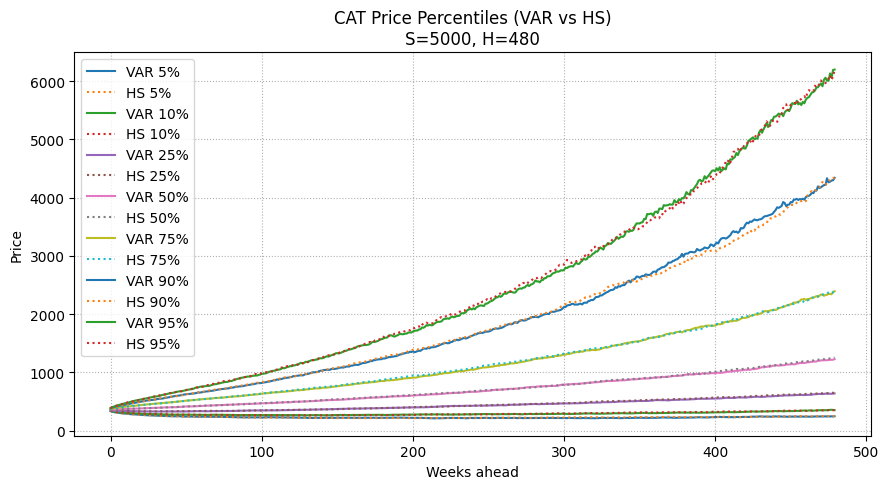

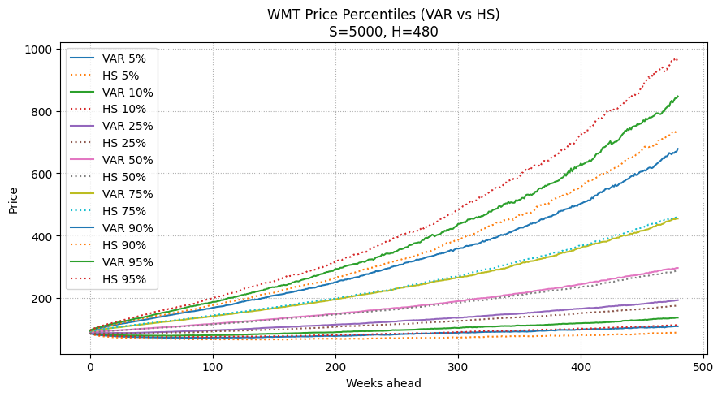

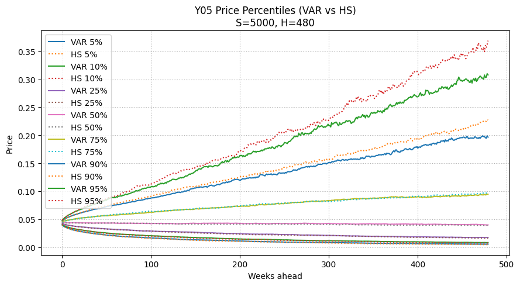

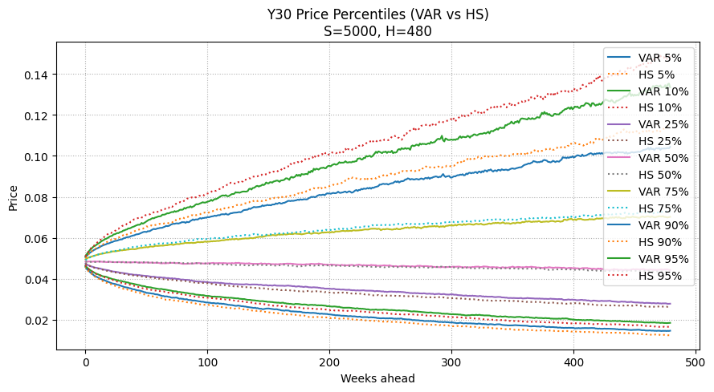

```python
for asset in assets_to_plot:
    idx = tickers.index(asset)

    # Compute percentiles
    q_var = np.percentile(price_paths_VAR[:, :, idx], q=percentiles, axis=0)
    q_hs  = np.percentile(price_paths_HS[:, :, idx],  q=percentiles, axis=0)

    # Plot both VAR and HS percentile
    plt.figure(figsize=(9, 5))
    for i, p in enumerate(percentiles):
        plt.plot(q_var[i, :], label=f"VAR {p}%", linewidth=1.5)
        plt.plot(q_hs[i, :], linestyle=':', label=f"HS {p}%", linewidth=1.5)

    plt.title(f"{asset} Price Percentiles (VAR vs HS)\nS={n}, H={steps}")
    plt.xlabel("Weeks ahead")
    plt.ylabel("Price")
    plt.legend()
    plt.grid(True, linestyle=':')
    plt.tight_layout()
    plt.show()


# Tables HS
perc_240_HS = np.percentile(price_paths_HS[:, 239, indices_assets], q=percentiles, axis=0).T
perc_480_HS = np.percentile(price_paths_HS[:, 479, indices_assets], q=percentiles, axis=0).T

df_240_HS = pd.DataFrame(perc_240_HS, columns=[f"{p}%" for p in percentiles], index=assets_to_plot)
df_480_HS = pd.DataFrame(perc_480_HS, columns=[f"{p}%" for p in percentiles], index=assets_to_plot)
```

```python
df_240_HS
```

|  | 5% | 10% | 25% | 50% | 75% | 90% | 95% |
| --- | --- | --- | --- | --- | --- | --- | --- |
| CAT | 216.838215 | 278.151298 | 426.190470 | 671.390656 | 1069.041096 | 1634.731969 | 2154.498240 |
| WMT | 70.766307 | 83.902705 | 113.436110 | 159.599681 | 223.132752 | 306.614851 | 375.061683 |
| Y05 | 0.009210 | 0.012624 | 0.022156 | 0.041401 | 0.077175 | 0.137663 | 0.197031 |
| Y30 | 0.019287 | 0.023546 | 0.032009 | 0.045889 | 0.066203 | 0.089589 | 0.107418 |

```python
df_480_HS
```

|  | 5% | 10% | 25% | 50% | 75% | 90% | 95% |
| --- | --- | --- | --- | --- | --- | --- | --- |
| CAT | 247.001614 | 350.485193 | 646.775498 | 1252.818101 | 2388.367289 | 4322.655087 | 6196.000079 |
| WMT | 87.717413 | 112.356389 | 174.977335 | 288.579616 | 461.665785 | 738.062523 | 974.599059 |
| Y05 | 0.004473 | 0.007436 | 0.016170 | 0.039461 | 0.097868 | 0.227344 | 0.369039 |
| Y30 | 0.012432 | 0.016409 | 0.026204 | 0.043655 | 0.072831 | 0.114708 | 0.148652 |

# 4. VAR(1)-DCC-model

Estimate a VAR(1)-DCC-model for the market

## a) Plot the ACF, for lags 1 to 50, for the (weekly) residuals and square residuals of the VAR-model, for Caterpillar and the 5-year interest rate.

Method:

- Defined a custom function to compute the autocorrelation function (ACF) for a given time series up to a specified number of lags.
- Applied the ACF function to the VAR(1) residuals and squared residuals of Caterpillar (CAT) and the 5-year interest rate (Y05) to check for serial correlation and volatility clustering.
- Calculated ACF values for 50 weekly lags for both residuals and squared residuals.
- Established 95% confidence intervals to visually assess the statistical significance of the correlations.

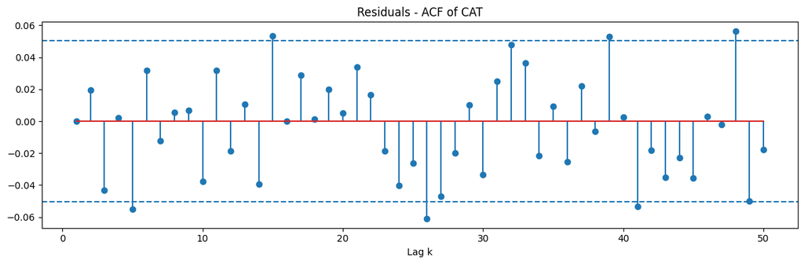

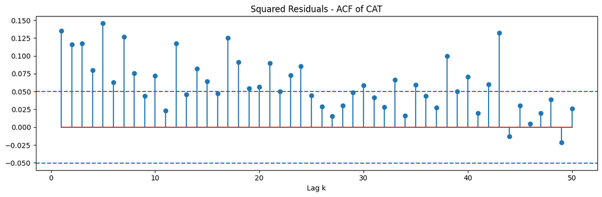

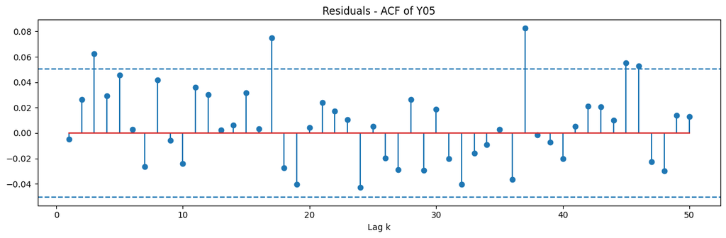

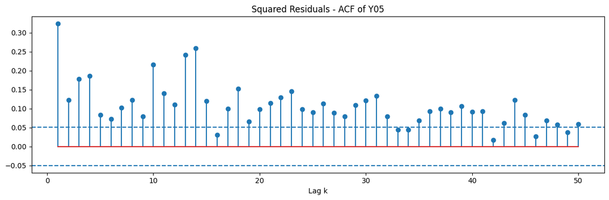

```python
def compute_acf(data, lag): #lecture2 slide 4,5,6
  y = np.asarray(data)
  T = len(y)
  y_bar = np.sum(y)/T
  C0 = np.sum((y - y_bar)**2) / T
  Ck = np.zeros(lag)
  for k in range(1, lag + 1):
    total = 0.0
    for t in range(0,T-k):
      total = total + (y[t] - y_bar) * (y[t+k] - y_bar)
    Ck[k-1] = total/T
  rho = Ck/C0
  return C0, Ck, rho

lag = 50

#CAT
C0_returns, Ck_returns, residuals_CAT = compute_acf(residuals_matrix[:, 1], lag)
C0_sq_returns, Ck_sq_returns, squared_residuals_CAT = compute_acf(residuals_matrix[:, 1]**2, lag)

#Y05
C0_returns, Ck_returns, residuals_Y05 = compute_acf(residuals_matrix[:, 10], lag)
C0_sq_returns, Ck_sq_returns, squared_residuals_Y05 = compute_acf(residuals_matrix[:, 10]**2, lag)

lags = np.arange(1, lag + 1)
ci = 1.96 / np.sqrt(T)

residuals_to_plot = [
    (residuals_CAT, "Residuals - ACF of CAT"),
    (squared_residuals_CAT, "Squared Residuals - ACF of CAT"),
    (residuals_Y05, "Residuals - ACF of Y05"),
    (squared_residuals_Y05, "Squared Residuals - ACF of Y05"),]

#Plots
for acf_vals, title in residuals_to_plot:
    plt.figure(figsize=(12, 4))
    plt.stem(lags, acf_vals)
    plt.axhline(ci, linestyle="--")
    plt.axhline(-ci, linestyle="--")
    plt.title(title)
    plt.xlabel("Lag k")
    plt.tight_layout()
    plt.show()
```

## b) Estimate the DCC-model and include the DCC-parameters in the report: delta, gamma, the R-matrix and the GARCH(1,1)-parameters as a 15*3-matrix

Method:

- Estimated univariate GARCH(1,1) models for each asset’s VAR(1) residuals using maximum likelihood estimation.
- Extracted and stored the estimated parameters (omega, alpha, beta) in a 15×3 matrix for all assets.
- Standardized the residuals using the estimated conditional volatilities.
- Computed the unconditional correlation matrix (R) from standardized residuals.
- Estimated the DCC parameters (delta and gamma) via grid search, maximizing the log-likelihood under the DCC specification while ensuring delta + gamma < 1 for stationarity.

```python
# GARCH likelihood from labb1
def garch_likelihood(params, returns):
    omega, alpha, beta = params
    T = len(returns)
    sigma2 = np.zeros(T)
    sigma2[0] = np.var(returns)
    for t in range(1, T):
        sigma2[t] = omega + alpha * returns[t-1]**2 + beta * sigma2[t-1]
    garch_likelihood.last_sigma2 = sigma2[-1]
    loglik = -0.5 * np.sum(np.log(sigma2) + returns**2 / sigma2)
    return -loglik  # minimize negative log-likelihood

init_params = [0.002, 0.06, 0.9]
bounds = [(1e-8, None), (0, 1), (0, 1)]
garch_params = []
sigmas = np.zeros_like(residuals_matrix)
for k in range(K):
    returns_k = residuals_matrix[:, k]
    res = minimize(garch_likelihood, init_params, args=(returns_k,), bounds=bounds)
    omega, alpha, beta = res.x
    garch_params.append([omega, alpha, beta])
    # Recompute sigma for the series
    T = len(returns_k)
    sigma2 = np.zeros(T)
    sigma2[0] = np.var(returns_k)
    for t in range(1, T):
        sigma2[t] = omega + alpha * returns_k[t-1]**2 + beta * sigma2[t-1]
    sigmas[:, k] = np.sqrt(sigma2)
garch_param_df = pd.DataFrame(garch_params, index=tickers, columns=['omega', 'alpha', 'beta'])
print("\nGARCH(1,1) Parameters:\n", garch_param_df)

# Standardize residuals
z = residuals_matrix / sigmas

# Estimate unconditional correlation R
S = np.cov(z, rowvar=False)
R = S / np.sqrt(np.outer(np.diag(S), np.diag(S)))
print("\nUnconditional R-matrix:\n", np.round(R, 3))

# Estimate DCC parameters (delta, gamma) by "simple "grid searchh
def dcc_loglik(z, R, delta, gamma):
    T, N = z.shape
    Q = R.copy()
    loglik = 0
    for t in range(T):
        Q = (1 - delta - gamma) * R + delta * np.outer(z[t], z[t]) + gamma * Q
        diag_sqrt = np.sqrt(np.diag(Q))
        R_t = Q / np.outer(diag_sqrt, diag_sqrt)
        invR = np.linalg.inv(R_t)
        sign, logdet = np.linalg.slogdet(R_t)
        loglik += -0.5 * (logdet + z[t].T @ invR @ z[t])
    return -loglik  # minimize

delta_range = np.linspace(0.01, 0.98, 10)
gamma_range = np.linspace(0.01, 0.98, 10)
best_ll = np.inf
best_delta = best_gamma = None
for delta in delta_range:
    for gamma in gamma_range:
        if delta + gamma < 1:
            ll = dcc_loglik(z, R, delta, gamma)
            if ll < best_ll:
                best_ll = ll
                best_delta, best_gamma = delta, gamma
print(f"\nDCC parameters: delta={best_delta:.4f}, gamma={best_gamma:.4f}")
```

```
GARCH(1,1) Parameters:
          omega     alpha      beta
BA    0.000066  0.101417  0.877349
CAT   0.000056  0.059076  0.913167
KO    0.000022  0.083976  0.893087
DIS   0.000019  0.051236  0.937503
JPM   0.000047  0.104266  0.874472
MMM   0.000013  0.045104  0.944002
MSFT  0.000034  0.065479  0.911801
PFE   0.000013  0.029625  0.959513
WMT   0.000020  0.045044  0.934977
XOM   0.000046  0.112444  0.849681
Y05   0.000010  0.101426  0.903003
Y10   0.000010  0.062209  0.930713
Y15   0.000008  0.060357  0.932537
Y20   0.000010  0.094008  0.899379
Y30   0.000020  0.128122  0.856966

Unconditional R-matrix:
 [[1.    0.447 0.343 0.41  0.411 0.442 0.274 0.284 0.256 0.393 0.191 0.158
  0.139 0.136 0.137]
 [0.447 1.    0.257 0.392 0.492 0.515 0.299 0.284 0.288 0.506 0.273 0.266
  0.261 0.265 0.253]
 [0.343 0.257 1.    0.349 0.326 0.411 0.297 0.372 0.355 0.367 0.042 0.019
  0.013 0.02  0.029]
 [0.41  0.392 0.349 1.    0.485 0.397 0.381 0.336 0.31  0.39  0.223 0.193
  0.174 0.17  0.182]
 [0.411 0.492 0.326 0.485 1.    0.442 0.345 0.34  0.313 0.402 0.302 0.294
  0.279 0.269 0.247]
 [0.442 0.515 0.411 0.397 0.442 1.    0.311 0.344 0.31  0.431 0.18  0.165
  0.155 0.154 0.159]
 [0.274 0.299 0.297 0.381 0.345 0.311 1.    0.283 0.327 0.262 0.168 0.136
  0.123 0.126 0.13 ]
 [0.284 0.284 0.372 0.336 0.34  0.344 0.283 1.    0.313 0.346 0.061 0.044
  0.047 0.059 0.069]
 [0.256 0.288 0.355 0.31  0.313 0.31  0.327 0.313 1.    0.255 0.101 0.078
  0.073 0.078 0.086]
 [0.393 0.506 0.367 0.39  0.402 0.431 0.262 0.346 0.255 1.    0.236 0.214
  0.203 0.207 0.221]
 [0.191 0.273 0.042 0.223 0.302 0.18  0.168 0.061 0.101 0.236 1.    0.931
  0.851 0.8   0.71 ]
 [0.158 0.266 0.019 0.193 0.294 0.165 0.136 0.044 0.078 0.214 0.931 1.
  0.975 0.937 0.84 ]
 [0.139 0.261 0.013 0.174 0.279 0.155 0.123 0.047 0.073 0.203 0.851 0.975
  1.    0.986 0.871]
 [0.136 0.265 0.02  0.17  0.269 0.154 0.126 0.059 0.078 0.207 0.8   0.937
  0.986 1.    0.911]
 [0.137 0.253 0.029 0.182 0.247 0.159 0.13  0.069 0.086 0.221 0.71  0.84
  0.871 0.911 1.   ]]

DCC parameters: delta=0.1178, gamma=0.8722
```

## c) Do 2.c) again and plot the price (or interest rate) percentiles (as dashed lines) in the same plot as the VAR(1)- and HS-percentiles

Method:

- Used the estimated parameters (A0, A, D, R, delta, gamma) to simulate dynamic conditional correlations and time-varying covariance matrices within the VAR(1)-DCC framework.
- Generated simulated return and price paths for all assets based on the evolving conditional covariance structure.
- For CAT, WMT, Y05, and Y30, overlaid all three sets of percentile curves in the same figure.

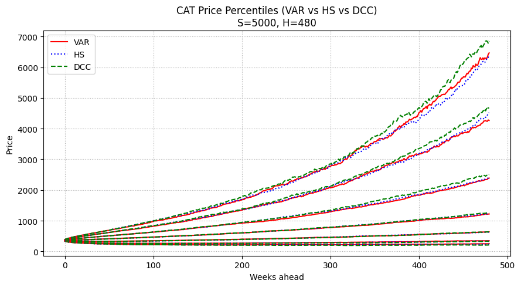

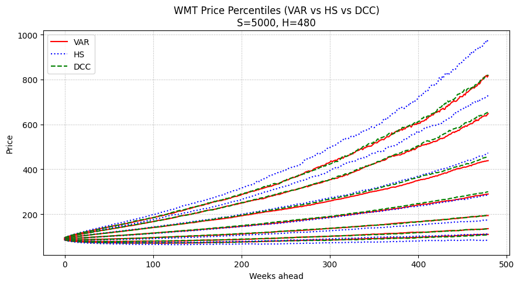

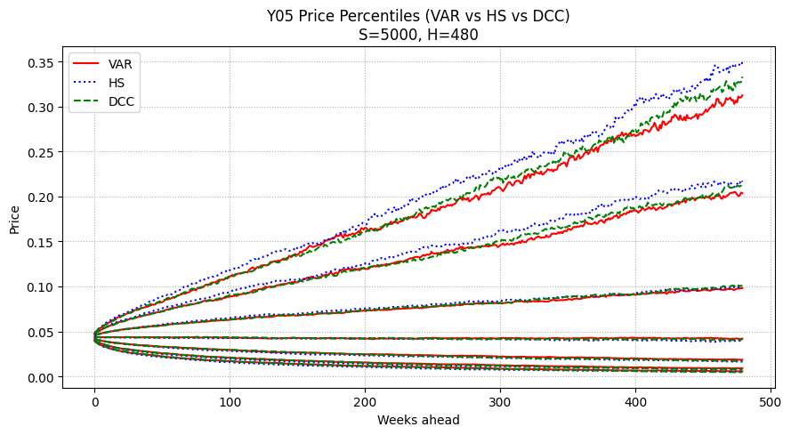

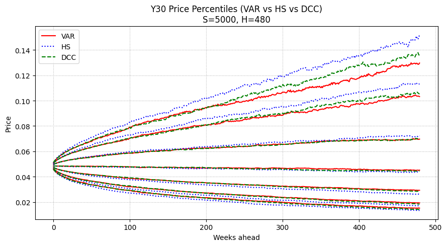

```python
# Simulate VAR(1)-DCC scenarios
n = 5000
steps = 480

y_last = log_returns.values[-1]
D_diag = np.std(residuals_matrix, axis=0)
D = np.diag(D_diag)
P0 = df.iloc[-1, :].values

def VAR_DCC(A0, A, y_last, D, R, delta, gamma, steps, n, P0):
    K = len(A0)
    ret_paths = np.zeros((n, steps, K))
    Q = np.tile(R, (n, 1, 1))  # (n, K, K)
    z_prev = np.zeros((n, K))
    y_prev = np.tile(y_last, (n, 1))
    for t in range(steps):
        outer_zz = z_prev[:, :, None] * z_prev[:, None, :]
        Q = (1 - delta - gamma) * R + delta * outer_zz + gamma * Q
        diag_sqrt = np.sqrt(np.diagonal(Q, axis1=1, axis2=2))
        diag_sqrt[diag_sqrt == 0] = 1e-8
        R_t = Q / (diag_sqrt[:, :, None] * diag_sqrt[:, None, :])
        Sigma_t = D @ R_t @ D
        eps = np.array([np.random.multivariate_normal(np.zeros(K), Sigma_t[i]) for i in range(n)])
        y_t = A0 + y_prev @ A.T + eps
        ret_paths[:, t, :] = y_t
        y_prev = y_t
        z_prev = eps / D_diag
    cum_log_ret = np.cumsum(ret_paths, axis=1)
    price_paths = np.exp(cum_log_ret) * P0
    return ret_paths, price_paths

ret_paths_dcc, price_paths_dcc = VAR_DCC(A0, A, y_last, D, R, best_delta, best_gamma, steps, n, P0)

for asset in assets_to_plot:
    idx = tickers.index(asset)

    # Percentiles for all 3 models
    q_var = np.percentile(price_paths_VAR[:, :, idx], q=percentiles, axis=0)
    q_hs  = np.percentile(price_paths_HS[:, :, idx],  q=percentiles, axis=0)
    q_dcc = np.percentile(price_paths_dcc[:, :, idx], q=percentiles, axis=0)

    # Plot all percentiles in same figure
    plt.figure(figsize=(9, 5))
    for i, p in enumerate(percentiles):
        # Only label once
        label_var = "VAR" if i == 0 else ""
        label_hs  = "HS" if i == 0 else ""
        label_dcc = "DCC" if i == 0 else ""

        plt.plot(q_var[i, :], linewidth=1.5, color='red', label=label_var)
        plt.plot(q_hs[i, :], linestyle=':', linewidth=1.5, color='blue', label=label_hs)
        plt.plot(q_dcc[i, :], linestyle='--', linewidth=1.5, color='green', label=label_dcc)

    plt.title(f"{asset} Price Percentiles (VAR vs HS vs DCC)\nS={n}, H={steps}")
    plt.xlabel("Weeks ahead")
    plt.ylabel("Price")
    plt.grid(True, linestyle=':')
    plt.legend()
    plt.tight_layout()
    plt.show()
```

```python
# Tables HS
perc_240_dcc = np.percentile(price_paths_dcc[:, 239, indices_assets], q=percentiles, axis=0).T
perc_480_dcc = np.percentile(price_paths_dcc[:, 479, indices_assets], q=percentiles, axis=0).T

df_240_dcc = pd.DataFrame(perc_240_dcc, columns=[f"{p}%" for p in percentiles], index=assets_to_plot)
df_480_dcc = pd.DataFrame(perc_480_dcc, columns=[f"{p}%" for p in percentiles], index=assets_to_plot)
```

```python
df_240_dcc
```

|  | 5% | 10% | 25% | 50% | 75% | 90% | 95% |
| --- | --- | --- | --- | --- | --- | --- | --- |
| CAT | 204.033208 | 263.055271 | 414.557351 | 668.096337 | 1089.800997 | 1673.052979 | 2187.975132 |
| WMT | 79.955544 | 94.008961 | 122.263977 | 162.186378 | 216.358209 | 282.725559 | 333.191060 |
| Y05 | 0.009409 | 0.013316 | 0.023005 | 0.042057 | 0.076675 | 0.132454 | 0.181918 |
| Y30 | 0.021042 | 0.024703 | 0.033987 | 0.046644 | 0.062814 | 0.083419 | 0.099461 |

```python
df_480_dcc
```

|  | 5% | 10% | 25% | 50% | 75% | 90% | 95% |
| --- | --- | --- | --- | --- | --- | --- | --- |
| CAT | 222.381735 | 337.865796 | 621.793436 | 1233.791409 | 2548.631866 | 4764.362123 | 7020.421528 |
| WMT | 105.371326 | 131.250635 | 192.806925 | 293.770505 | 439.113171 | 641.626325 | 812.010179 |
| Y05 | 0.004743 | 0.007556 | 0.016342 | 0.038857 | 0.092599 | 0.212679 | 0.347558 |
| Y30 | 0.014455 | 0.018743 | 0.028251 | 0.044211 | 0.069480 | 0.105893 | 0.131700 |

# Discussion

*What does a) tell you?*

The ACF plots of the residuals and squared residuals for Caterpillar (CAT) and the 5-year interest rate (Y05) indicate that the model has not fully captured all the serial dependence and volatility dynamics in the data. For both series, several autocorrelation coefficients in the residuals lie outside the 95% confidence bounds, suggesting the presence of remaining linear dependence and that the residuals are not completely white noise. Moreover, the squared residuals exhibit clear and persistent autocorrelation. These results show that the variance of the residuals changes over time and that the model fails to describe the time-varying volatility structure of the data. Consequently, this motivates the use of a DCC-GARCH model in the following parts, as it can capture the dynamic correlations between the assets.

# 5. Explore the data

You can do this part of the assignment in Excel (in that case submit also the Excel file).

## a) Plot the average, over the five years of data, of the mean population for each age for both men and women in the same figure.

Method:

- Constructed a dataset based on demographic data from SCB for easier computation. Column 1-5 were popoluation per age group for men, column 6-10 were the same for women. Column 11-15 were death per age group for men and column 16-20 were death per age group for women.
- Imported demographic data from “scb_data.xlsx”.
- Extracted the columns corresponding to male and female population counts over five years.
- Computed the average population across those five years for each age group separately for men and women.
- Plotted both average age distributions in the same figure to compare gender-based population patterns.

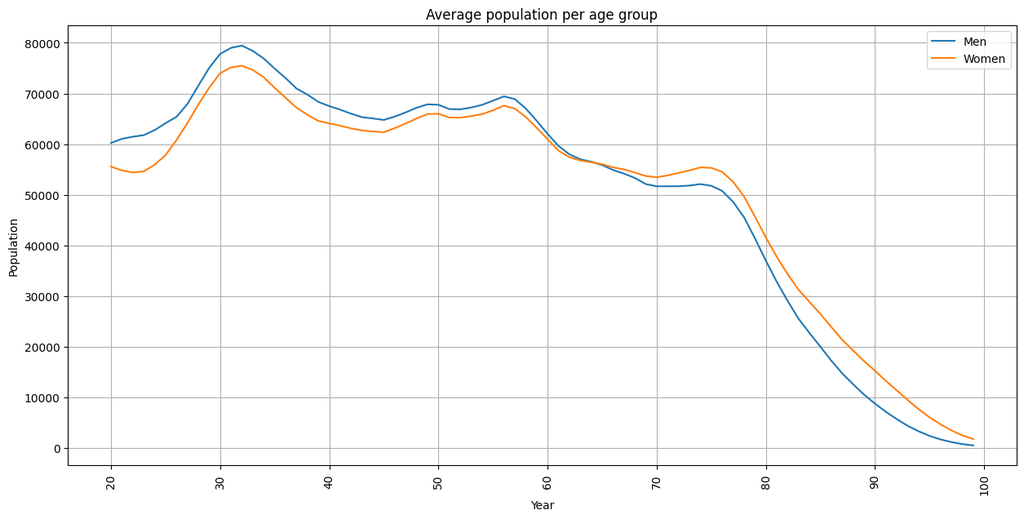

```python
df = pd.read_excel("scb_data.xlsx")

df_population_men = df[df.columns[1:6]]
df_population_women = df[df.columns[6:11]]

df_population_men.mean(axis=1).iloc[:].plot(figsize = (15,7), label = "Men")
df_population_women.mean(axis=1).iloc[:].plot(figsize = (15,7), label = "Women")

plt.xticks(ticks=range(0,81,10), labels=range(20,101,10), rotation=90)
plt.xlabel("Year")
plt.ylabel("Population")
plt.title("Average population per age group")
plt.legend()
plt.grid(True)
plt.show()
```

## b) Plot the average, over the five years of data, of the number of deaths for each age for both men and women in the same figure.

Method:

- Selected the columns representing the number of deaths for men and women over five years from the dataset.
- Calculated the average number of deaths per age group across the five-year period for each gender.
- Plotted both male and female averages in the same figure to visualize mortality differences by age.

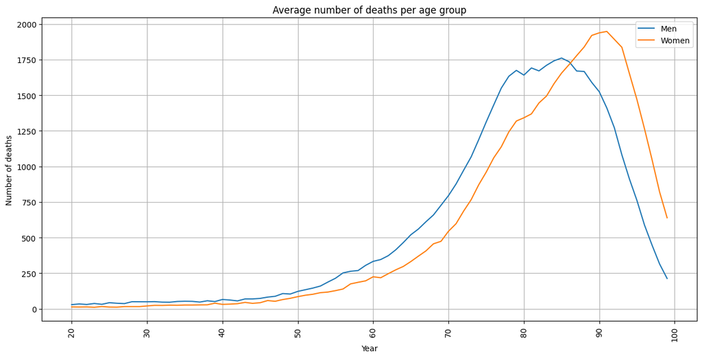

```python
df_deaths_men = df[df.columns[11:16]]
df_deaths_women = df[df.columns[16:21]]
df_deaths_men.mean(axis=1).iloc[:].plot(figsize = (15,7), label = "Men")
df_deaths_women.mean(axis=1).iloc[:].plot(figsize = (15,7), label = "Women")

plt.xticks(ticks=range(0,81,10), labels=range(20,101, 10), rotation=90)
plt.xlabel("Year")
plt.ylabel("Number of deaths")
plt.title("Average number of deaths per age group")
plt.legend()
plt.grid(True)
plt.show()
```

## Discussion

*What do these plots tell you?*

# 6. Mortality estimation

## a) Estimate the force of mortality for men and women separately using the SCB-data and plot these estimates in the same figure. Do this for ages 20 – 99 and use data for all five years for a more stable estimate.

Method:

- Calculated the total number of deaths and total population for each age group across all five years.
- Computed the force of mortality (μ) for men and women separately as the ratio of total deaths to total population for each age.
- Stored the resulting mortality rates for ages 20–99 in separate series for men and women.
- Plotted both mortality curves in the same figure to compare gender-specific mortality patterns by age.

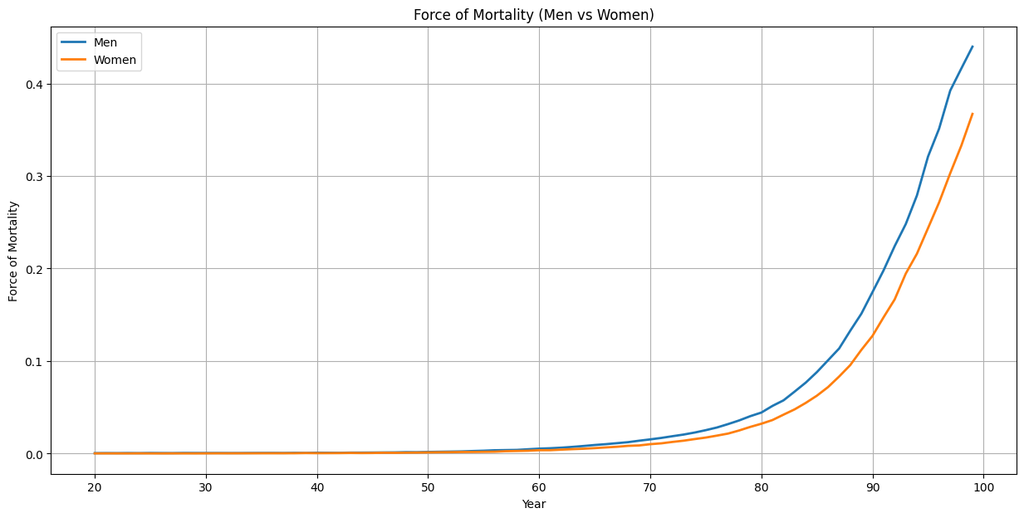

```python
force_mortality_men = []
force_mortality_women = []

for i in range(len(df_deaths_men)):
    # Men
    deaths_sum_men = df_deaths_men.iloc[i].sum()
    pop_sum_men = df_population_men.iloc[i].sum()
    mu_men = deaths_sum_men / pop_sum_men
    force_mortality_men.append(mu_men)

    # Women
    deaths_sum_women = df_deaths_women.iloc[i].sum()
    pop_sum_women = df_population_women.iloc[i].sum()
    mu_women = deaths_sum_women / pop_sum_women
    force_mortality_women.append(mu_women)


ages_2099 = range(20, 100)  # 80 age groups

mu_men_series = pd.Series(force_mortality_men)
mu_women_series = pd.Series(force_mortality_women)

plt.figure(figsize=(15, 7))
plt.plot(ages_2099, mu_men_series, label="Men", linewidth=2)
plt.plot(ages_2099, mu_women_series, label="Women", linewidth=2)

plt.xlabel("Year")
plt.ylabel("Force of Mortality")
plt.title("Force of Mortality (Men vs Women)")
plt.legend()
plt.grid(True)
plt.show()
```

## b) Fit Makeham functions using only force of mortality estimates for ages 20 – 90 from above. Then plot the estimated forces of mortality, for ages 20 – 99, together with the Makeham functions in the same figure (both men and women). Include the parameters in the report.

Method:

- Selected force of mortality estimates for ages 20–90 for both men and women to fit Makeham mortality models.
- Defined an optimization function to minimize the sum of squared errors between observed and model-implied mortality rates.
- Solved for the Makeham parameters (α, β, γ) separately for men and women using nonlinear optimization.
- Computed fitted Makeham mortality curves across the full age range (20–99).
- Plotted the observed mortality estimates together with the fitted Makeham functions (as dashed lines) for visual comparison.

```
Makeham parameters for Men:
Alpha: 0.001232
Beta: 0.00000111
Gamma: 0.132669

Makeham parameters for Women:
Alpha: 0.000771
Beta: 0.00000056
Gamma: 0.136789
```

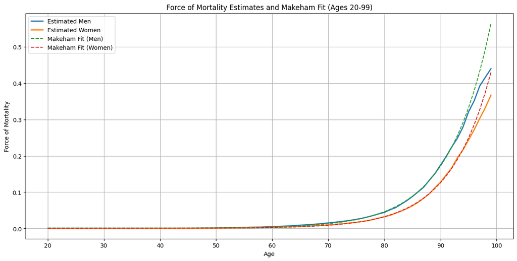

```python
ages = range(20,91)

mu_men_array_cut = mu_men_series.values[0:71]
mu_women_array_cut = mu_women_series.values[0:71]

mu_men_array = mu_men_series.values
mu_women_array = mu_women_series.values
ages_array = np.array(ages)


# Initial guess for gamma
gamma_initial = float(0.1)

def gamma_optim(gamma, mu_values, ages):
    N = len(ages)
    f1_gamma = np.sum(np.exp(gamma * ages))
    f2_gamma = np.sum(np.exp(2 * gamma * ages))
    g_gamma = np.sum(mu_values * np.exp(gamma * ages))
    m = np.sum(mu_values)

    # Solve for alpha and beta
    alpha = ((m * f2_gamma) - (g_gamma * f1_gamma)) / ((N * f2_gamma) - (f1_gamma ** 2))
    beta = ((m * f1_gamma) - (N * g_gamma)) / ((f1_gamma ** 2 ) - (N * f2_gamma))

    #  sum of squared errors
    predicted_mu = alpha + beta * np.exp(gamma * ages)
    diff_errors = predicted_mu - mu_values
    sse = np.sum((diff_errors)**2)
    return sse

def fit_makeham(ages, mu_values, gamma_initial):
    N = len(ages)
    # Optimize for gamma
    result = minimize(gamma_optim, gamma_initial, args=(mu_values, ages))
    gamma = result.x[0]

    # Calculate alpha and beta with optimized gamma
    f1_gamma = np.sum(np.exp(gamma * ages))
    f2_gamma = np.sum(np.exp(2 * gamma * ages))
    g_gamma = np.sum(mu_values * np.exp(gamma * ages))
    m = np.sum(mu_values)

    alpha = ((m * f2_gamma) - (g_gamma * f1_gamma)) / ((N * f2_gamma) - (f1_gamma ** 2))
    beta = ((m * f1_gamma) - (N * g_gamma)) / ((f1_gamma ** 2 ) - (N * f2_gamma))

    return alpha, beta, gamma


def makeham_function(X_i, alpha, beta, gamma):
  mu_values = alpha + beta * np.exp(gamma * X_i)
  return mu_values

# Fit Makeham for men
alpha_men, beta_men, gamma_men = fit_makeham(ages_array, mu_men_array_cut, gamma_initial)

# Fit Makeham for women
alpha_women, beta_women, gamma_women = fit_makeham(ages_array, mu_women_array_cut, gamma_initial)

print("Makeham parameters for Men:")
print(f"Alpha: {alpha_men:.6f}")
print(f"Beta: {beta_men:.8f}")
print(f"Gamma: {gamma_men:.6f}")

print("\nMakeham parameters for Women:")
print(f"Alpha: {alpha_women:.6f}")
print(f"Beta: {beta_women:.8f}")
print(f"Gamma: {gamma_women:.6f}")


# Plots / Results
plt.figure(figsize=(15, 7))
plt.plot(ages_2099, mu_men_array, label="Estimated Men", linewidth=2)
plt.plot(ages_2099, mu_women_array, label="Estimated Women", linewidth=2)

plt.plot(ages_2099, makeham_function(ages_2099, alpha_men, beta_men, gamma_men), label="Makeham Fit (Men)", linestyle='--')
plt.plot(ages_2099, makeham_function(ages_2099, alpha_women, beta_women, gamma_women), label="Makeham Fit (Women)", linestyle='--')

plt.xlabel("Age")
plt.ylabel("Force of Mortality")
plt.title("Force of Mortality Estimates and Makeham Fit (Ages 20-99)")
plt.legend()
plt.grid(True)
plt.show()
```

## c) Plot the survival functions for men and women, for ages 0 – 105, in the same figure (but not the same as in b).

Method:

- Defined the survival function based on the Makeham mortality model using the estimated parameters (α, β, γ).
- Computed survival probabilities for ages 0–105 separately for men and women.
- Generated survival curves showing the probability of surviving from birth to each age.
- Plotted both male and female survival functions in the same figure for direct comparison.

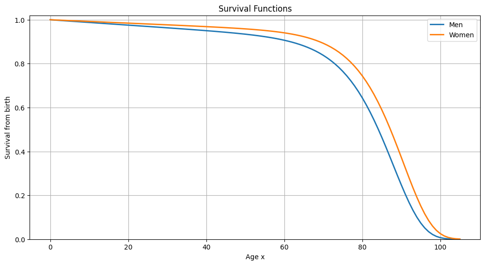

```python
ages_new = range(0,106)

def survival(x, alpha, beta, gamma):

    return np.exp(-alpha*x - (beta/gamma) * np.exp(gamma*x))

l_men   = survival(ages_new,   alpha_men,   beta_men,   gamma_men)
l_women = survival(ages_new, alpha_women, beta_women, gamma_women)

plt.figure(figsize=(12,6))
plt.plot(ages_new, l_men,   label="Men",   linewidth=2)
plt.plot(ages_new, l_women, label="Women", linewidth=2)
plt.ylim(0, 1.02)
plt.xlabel("Age x")
plt.ylabel("Survival from birth")
plt.title("Survival Functions")
plt.grid(True); plt.legend(); plt.show()
```

## d) Calculate life expectancy for both men and women, according to the lifetime distributions given by the Makeham functions.

Method:

- Defined integrand functions for men and women based on their respective Makeham survival functions.
- Calculated life expectancy as the integral of the survival function from age 0 to 120, representing the expected remaining lifetime at birth.
- Performed numerical integration using the quad function to obtain precise estimates.

```python
# Function to integrate for life expectancy
def integrand_men(x):
    return survival(x, alpha_men, beta_men, gamma_men)

def integrand_women(x):
    return survival(x, alpha_women, beta_women, gamma_women)

# We will integrate up to age 120, as survival probability is close to zero after this age.
life_expectancy_men, error_men = quad(integrand_men, 0, 120)
life_expectancy_women, error_women = quad(integrand_women, 0, 120)
print(life_expectancy_men)
print(life_expectancy_women)

print(f"Life Expectancy for Men: {life_expectancy_men:.2f} years")
print(f"Life Expectancy for Women: {life_expectancy_women:.2f} years")
```

```
79.52822140114304
83.57063122107128
Life Expectancy for Men: 79.53 years
Life Expectancy for Women: 83.57 years
```

# 7. 1st order payout and reserve

Calculate the guaranteed payout amount and project the 1st order reserve for the policy.

## a) Determine the yearly payout amount, b.

Method:

- Set contract inputs: current age (x), retirement age (z), payout length (s), time to retirement (u), guaranteed interest rate, initial reserve (G0), and annual premium.
- Converted the guaranteed rate to a force of interest $(δ_g = ln(1 + rate))$ for continuous compounding.
- Computed the present value of benefits by summing monthly payments from retirement to the end of the payout period, weighting each month by survival from age x and discounting at δ_g.
- Computed the present value of premiums by summing monthly premiums from issue to retirement, also weighted by survival and discounted at δ_g.
- Solved for the level yearly payout b by equaling the PV-payout function with the PV-premium function.
- Evaluated survival probabilities using the previously fitted Makeham parameters (women) for consistency with earlier mortality estimations.

```python
x = 60                          #current age
z = 65                          #retirement age
s = 120 - z                     #length of payout period
u = z - x                       #time to retirement
rate = 0.02                     #Guaranteed interest rate
G_0 = 2000000                   #reserve at time 0 (age 60)
premium = 120000                # annual premium
delta_g = np.log(1 + rate)      #discount factor

PV_payout = 0
for t in np.arange(12 * u + 1, 12 * (u + s) + 1):
    surv_ratio = survival(x + t/12, alpha_women, beta_women, gamma_women) / survival(x, alpha_women, beta_women, gamma_women)
    discount = np.exp(-delta_g * t/12)
    PV_payout = PV_payout + surv_ratio * discount

PV_premiums = 0
for t in np.arange(1, 12 * u + 1):
    surv_ratio = survival(x + t/12, alpha_women, beta_women, gamma_women) / survival(x, alpha_women, beta_women, gamma_women)
    discount = np.exp(-delta_g * t/12)
    PV_premiums = PV_premiums + surv_ratio * discount

b = float(12 * (G_0 + (premium / 12) * PV_premiums) / PV_payout)
print(b)
```

```
165727.18014913402
```

## b) Plot the evolution of the reserve 30 years into the future.

Method:

- Computed the monthly evolution of the reserve over 30 years, accounting for premium payments before retirement and benefit payouts afterward.
- Recorded the reserve values at selected time points (0, 60, 120, 180, 240, 300, 360 months) to summarize key stages of the contract.
- Plotted the reserve curve to illustrate the reserve’s progression over time.
- Created a table displaying the reserve amount and corresponding ages for these intervals.

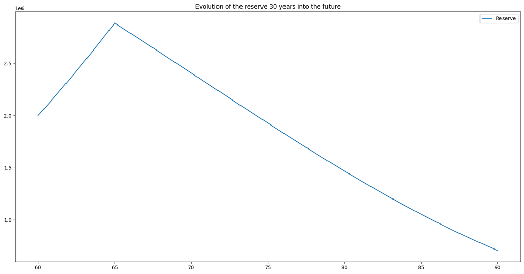

```python
monthly_premium = premium/12
length = 360
risk_premium = np.empty(length + 1)

for t in range(0, length + 1):
    q_m = 1 - (survival(x + (t + 1)/12,alpha_women, beta_women, gamma_women) / survival(x + t/12,alpha_women, beta_women, gamma_women))
    risk_premium[t] = q_m / (1 - q_m)

reserve = np.zeros(length + 1) # Initialize reserve as an array
reserve[0] = G_0
for i in range(1, length + 1):
    if x + i/12 > z:
        reserve[i] = reserve[i-1] * np.exp(delta_g/12) + reserve[i-1] * risk_premium[i-1] - b/12
    else:
        reserve[i] = reserve[i-1] * np.exp(delta_g/12) + reserve[i-1] * risk_premium[i-1] + monthly_premium

per_age = x + np.arange(0, length + 1)/12
plt.figure(figsize = (18,9))
plt.plot(per_age, reserve, label = "Reserve")
plt.title("Evolution of the reserve 30 years into the future")
plt.legend()
```

```python
table = [0, 60, 120, 180, 240, 300, 360]
df_7 = pd.DataFrame({"Value of the reserve": reserve[table],"Age" : np.array(table)/12 + x})
pd.options.display.float_format = '{:.0f}'.format
df_7
```

|  | Value of the reserve | Age |
| --- | --- | --- |
| 0 | 2000000 | 60 |
| 1 | 2887851 | 65 |
| 2 | 2408213 | 70 |
| 3 | 1927951 | 75 |
| 4 | 1468495 | 80 |
| 5 | 1054289 | 85 |
| 6 | 706641 | 90 |